# SuperFarmer - symulacja rozgrywki jednoosobowej

Aleksandra Dąbrowska

Alicja Gosiewska

# 1 Rozważany problem

Zajmujemy się symulacją gry “SuperFarmer”.

Gracz jest hodowcą zwierząt i pragnie zostać superfarmerem. Gracz zwiększa swój zysk rozmnażając zwierzęta. Może zamieniać wyhodowane zwierzęta na inne, jeśli uzna,że to mu się opłaca. Aby zwyciężyć, musi uzyskać stado złożone, co najmniej z konia, krowy, świni, owcy i królika. Przeszkodą w zdobyciu wszytkich zwierząt są pojawiające się w grze wilki i lisy, które mogą osłabić stado gracza. Początkowo nasz gracz nie ma żadnych zwierząt. Aby zdobyć zwierzęta rzuca dwiema dwunastościennymi kośćmi.

# 2 Funkcje

W naszym programie stworzyłyśmy 13 funkcji pozwalających zasymulować rozgrywkę.

## 2.1 Wygenerowanie struktur potrzebnych do gry

Funkcja tworzy dataframes przechowujące:

stan głównego stada - stado

| krolik | owca | swinia | krowa | kon | maly_pies | duzy_pies |
| --- | --- | --- | --- | --- | --- | --- |
| 57 | 21 | 19 | 11 | 5 | 4 | 1 |

stan stada gracza - stado_g1

| krolik | owca | swinia | krowa | kon | maly_pies | duzy_pies |
| --- | --- | --- | --- | --- | --- | --- |
| 3 | 3 | 1 | 1 | 1 | 0 | 1 |

wyniki rzutów kośćmi w kolejnych rundach - zapis_gry_g1

| krolik | owca | swinia | krowa | kon | lis | wilk |
| --- | --- | --- | --- | --- | --- | --- |
| 0 | 0 | 0 | 0 | 0 | 0 | 0 |
| 2 | 0 | 0 | 0 | 0 | 0 | 0 |
| 1 | 0 | 0 | 0 | 1 | 0 | 0 |
| 0 | 1 | 1 | 0 | 0 | 0 | 0 |
| 1 | 0 | 0 | 1 | 0 | 0 | 0 |
| 0 | 1 | 1 | 0 | 0 | 0 | 0 |

```r
przed_wyruszeniem_w_droge_nalezy_zebrac_druzyne <- function(){
stado <- data.frame(t(c(60,24,20,12,6,4,2)))
colnames(stado) <- c("krolik","owca","swinia", "krowa", "kon", "maly_pies","duzy_pies")

stado_g1 <- data.frame(t(c(0,0,0,0,0,0,0)))
colnames(stado_g1) <- c("krolik","owca","swinia", "krowa", "kon", "maly_pies","duzy_pies")

zapis_gry_g1 <- data.frame(t(c(0,0,0,0,0,0,0)))
colnames(zapis_gry_g1) <- c("krolik","owca","swinia", "krowa", "kon","lis","wilk")

stado <<- stado

stado_g1 <<- stado_g1

zapis_gry_g1 <<- zapis_gry_g1
}
```

## 2.2 Symulacja rzutu kostkami

Funkcja symuluje rzut dwiema kostkami. Zwraca ona dwie zmienne typu character odpowiadające wylosowanym na kostkach zwierzętom.

```r
rzut <- function(){
                  d1 <- sample(1:12,1)
                  d2 <- sample(1:12,1)
                  if(d1==1) {d1_value="wilk"}
                  if (d1==2) {d1_value="krowa"}
                  if(d1==3) {d1_value="swinia"}
                  if(d1==4 || d1==5 || d1==6) {d1_value="owca"}
                  if(d1>6) {d1_value="krolik"}

                  if(d2==1) {d2_value="lis"}
                  if(d2==2) {d2_value="kon"}
                  if(d2==3 || d2==4) {d2_value="swinia"}
                  if(d2==5 || d2==6) {d2_value="owca"}
                  if(d2>6) {d2_value="krolik"}

                  return(c(d1_value,d2_value))
}
```

## 2.3 Efekt rzutu kostkami na stan stada

Funkcja wywołuje funkcję rzut() oraz zmienia stany stada głównego i stada gracza, w zależności od wyniku rzutu kośćmi. Wyniki poszczególnych rzutów zostają zapisane do tabeli zapis_gry_g1.

```r
przebieg_rzutu_g1<- function(){
           rzut_g1 <- rzut()

           zapis_gry_g1[nrow(zapis_gry_g1)+1,]<<-c(0,0,0,0,0,0,0)
           zapis_gry_g1[nrow(zapis_gry_g1),rzut_g1[1]]<<-zapis_gry_g1[nrow(zapis_gry_g1),rzut_g1[1]]+1
           zapis_gry_g1[nrow(zapis_gry_g1),rzut_g1[2]]<<-zapis_gry_g1[nrow(zapis_gry_g1),rzut_g1[2]]+1

          if(rzut_g1[1]=="wilk"){
            if(stado_g1$duzy_pies > 0){
              stado_g1$duzy_pies <<- stado_g1$duzy_pies-1
              stado$duzy_pies <<- stado$duzy_pies+1
            }else{
              stado[,-5] <<- stado[,-5] + stado_g1[,-5]
              stado_g1[,-5] <<- c(0,0,0,0,0,0)
            }}
           if(rzut_g1[2]=="lis"){
            if(stado_g1$maly_pies > 0){
              stado_g1$maly_pies <<- stado_g1$maly_pies-1
              stado$maly_pies <<- stado$maly_pies+1
            }else{
              stado[,1] <<- stado[,1]+stado_g1[,1]
              stado_g1[,1] <<- 0
            }}

           for (i in 1:5){
             if(zapis_gry_g1[nrow(zapis_gry_g1),i]>0){
               tmp <- floor((zapis_gry_g1[nrow(zapis_gry_g1),i]+stado_g1[1,i])/2)
               if(stado[1,i]>= tmp){
               stado_g1[1,i] <<- stado_g1[1,i]+tmp
               stado[1,i] <<- stado[1,i]-tmp
               }
               else{
               stado_g1[1,i] <<- stado_g1[1,i]+stado[1,i]
               stado[1,i] <<- 0
               }
               }
           }


}
```

Przebieg rzutu prezentują poniższe schematy:

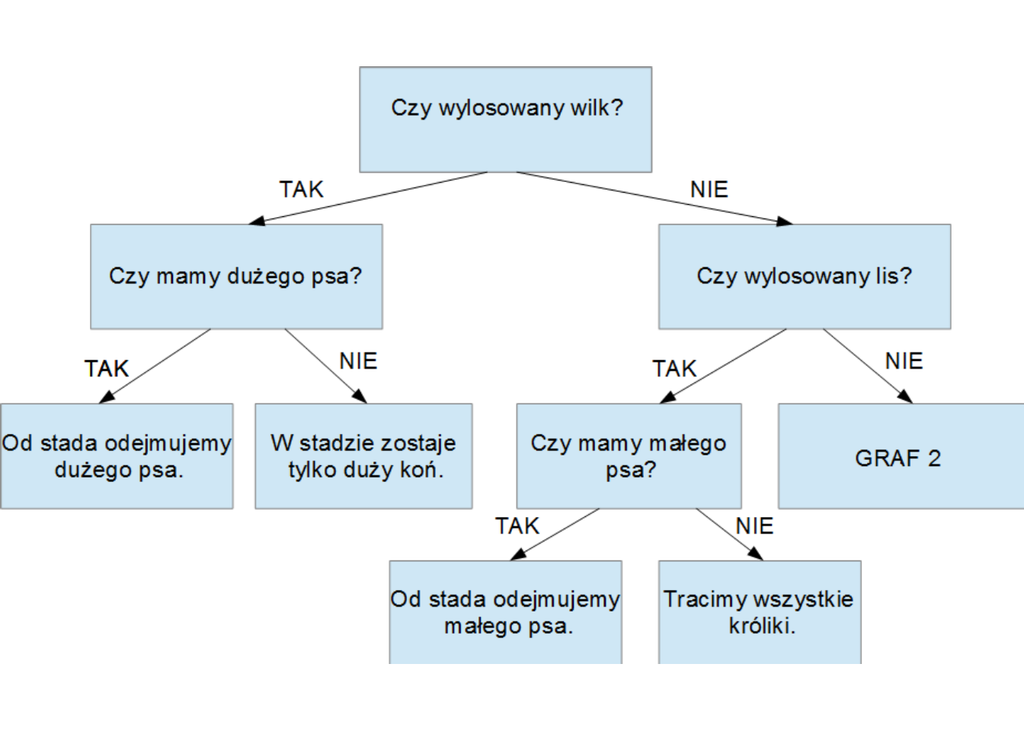

GRAF2

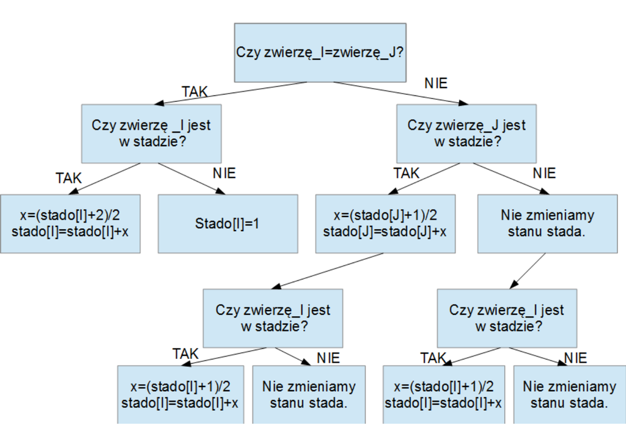

## 2.4 Sprawdzenie wartości zwierzęcia (wyrażona w królikach)

Funkcja pobiera argument typu charakter zawierający nazwę zwierzęcia i zwraca zmienna typu numeric, która oznacza wartość danego zwierzęcia.

```r
wartosc <- function(zwierze){
   if(zwierze=="krolik") wart <- 1
  if(zwierze=="owca") wart <- 6
  if(zwierze=="swinia") wart <- 12
  if(zwierze=="krowa") wart <- 36
  if(zwierze=="kon") wart <- 72
  if(zwierze=="maly_pies") wart <- 6
  if(zwierze=="duzy_pies") wart <- 36
  return(wart)
}
```

## 2.5 Sprawdzenie możliwości dokonania wymiany i zwrócenie jej efektu

Funkcje w tej sekcji zwracają wartości TRUE lub FALSE, w zależności, czy pożądana wymiana może zostać dokonana. Ponadto tworzą też tabelę symulujące zmiany stanów stada głównego i stada gracza w przypadku dokonania wymiany.

### 2.5.1 Wymiana jednego zwierzęcia na kilka innych

Argumenty:

co (character) - nazwa zwierzęcia, które chemy wymienić

na_co (character) - nazwa zwierzęcia, które chcemy dostać

Opis działania:

Funkcja bierze maksymalną możliwą do wymiany liczbę zwierząt gatunku, który chcemy dostać. W przypadku, gdy nie wykorzystamy całej wartości zwierzęcia, które wymieniamy, dobiera zwierzęta innych gatunków (od najbardziej wartościowego).

```r
jedno_na_kilka <- function(co,na_co){
  budzet <- wartosc(co)
  cena <- wartosc(na_co)

  dostaniemy <- data.frame(t(c(0,0,0,0,0,0,0)))
  colnames(dostaniemy) <- c("krolik","owca","swinia", "krowa", "kon", "maly_pies","duzy_pies")

  dostaniemy[1,na_co] <- min(floor((budzet)/cena),stado[1,na_co])
  budzet_temp <- budzet - dostaniemy[1,na_co]*cena
  i <- 7
  while(budzet_temp>0 && i>=1){
    cena <- wartosc(colnames(dostaniemy[i]))
    dostaniemy[1,i] <- min(floor((budzet_temp)/cena),stado[1,i])
    budzet_temp <- budzet_temp - dostaniemy[1,i]*cena

    i <- i-1
  }
  dostaniemy[1,co] <- (-1)
  dostaniemy<<-dostaniemy
  if(budzet_temp>0 || dostaniemy[1,na_co]==0) return(0)

  return(1)
}
```

Argumenty:

co (dataframe) - ramka danych zawierająca liczbę i gatunki zwierzat, które chcemy wymienić

| krolik | owca | swinia | krowa | kon | maly_pies | duzy_pies |
| --- | --- | --- | --- | --- | --- | --- |
| 57 | 21 | 19 | 11 | 5 | 4 | 1 |

na_co (character) - nazwa zwierzęcia, które chcemy dostać

Opis działania:

Funkcja korzysta z funkcji jedno_na_kilka wywołując ją dla poszczególnych zwierząt z tabeli zawierającej zwierzęta, które chcemy wymienić.

```r
jedno_na_kilka_upgraded <- function(co,na_co){
  kolejnosc <- c(5,4,3,2,1,6,7)
  for (i in 1:7){
    if (co[1,kolejnosc[i]] >0){
      if(jedno_na_kilka(colnames(co)[kolejnosc[i]],na_co)==1){
        return(1)
      }
    }
  }
  return(0)
}
```

### 2.5.2 Wymiana kilku zwierząt na jedno

Argumenty:

co (dataframe) - ramka danych zawierająca liczbę i gatunki zwierzat, które chcemy wymienić

na_co (character) - nazwa zwierzęcia, które chcemy dostać

Opis działania:

Funkcja sprawdza czy to co chcemy oddać wystarczy na wymianę na wybrany jeden gatunek zwierzęcia.

```r
kilka_na_jedno <- function(co, na_co){
        cena <- wartosc(na_co)
        kolejnosc <- c(4,3,2,1,6,7)
        oddamy <- data.frame(t(c(0,0,0,0,0,0,0)))
        colnames(oddamy) <- c("krolik","owca","swinia", "krowa", "kon", "maly_pies","duzy_pies")
        for (i in 1:6){
          j <- colnames(oddamy)[kolejnosc[i]]
          if(co[1,j]>0 && wartosc(j)<=cena){
          oddamy[1,j]<-min(floor(cena/wartosc(j)),co[1,j])
          cena <- cena-oddamy[1,j]*wartosc(j)
          }
        }
        oddamy[1,na_co] <- (-1)
        oddamy<<- (-oddamy)
        if(cena>0){
          return(0)
        }
        return(1)
}
```

## 2.6 Wyegzekwowanie zmian stanów stad

Funkcja na wejściu dostaje ramkę danych przechowującą wynik wymiany i zmienia stan poszczególnych stad zgodnie z jej stanem.

```r
dokonanie_wymian <- function(tabela){
      stado_g1 <<- stado_g1 + tabela
      stado <<- stado - tabela
}
```

## 2.7 Sprawdzenie obecnej wartości stanu stada gracza (wyrazonej w królikach)

Funkcja otrzymuje ramkę danych zawierającą stan stada gracza w danej chwili. I oblicza łączną wartość posiadanych przez niego zwierząt.

```r
wyciag_z_konta <- function(tabela){
  saldo <- 0
  for(i in 1:7){
    saldo <- saldo + tabela[1,i]*wartosc(colnames(tabela)[i])
  }
  return(saldo)
}
```

## 2.8 Sprawdzenie, czy warunki wygranej są spełnione

Funkcja sprawdza czy podana na wejściu ramka danych zawiera gatunki zwierząt wymagane do wygranej.

```r
czy_wygrana <- function(table){
  for(i in 1:5){
    if(table[1,i]==0) return("Próbuj dalej :)")
  }
  return("Jestes zwyciezca!")
}
```

## 2.9 Implementacja strategii

Naszą strategię gry i wymian prezentuje poniższy schemat:

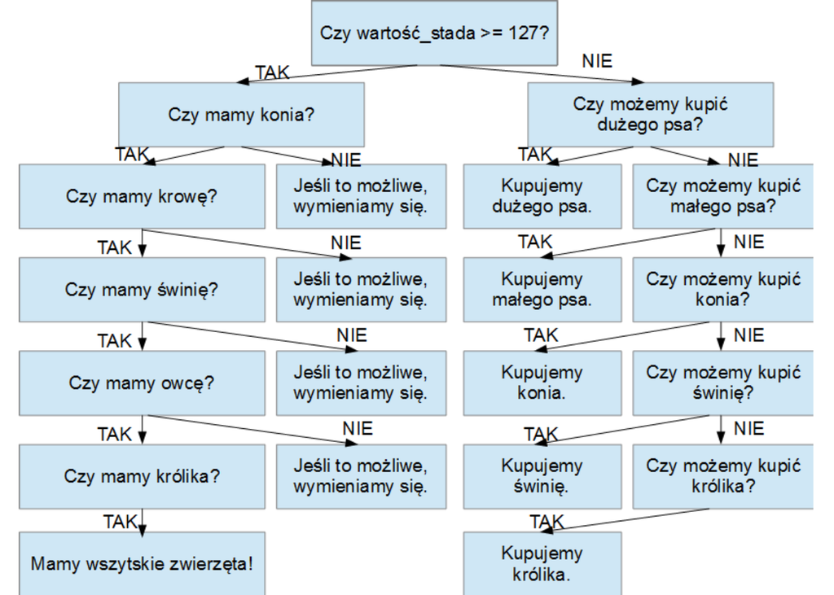

Funkcja zwraca wartość “1” jeśli dokonaliśmy wymiany, “0” w przeciwnym razie.

```r
strategia_wymian <- function(){
if(wyciag_z_konta(stado_g1)>=127){
  wymieniamy <- (stado_g1 -1)
  wymieniamy[wymieniamy==-1] <-0
  if(stado_g1$kon==0){
    if(kilka_na_jedno(wymieniamy,"kon")==1){
      dokonanie_wymian(oddamy)
      return(1)
    }
  }else if(stado_g1$krowa==0){
    if(kilka_na_jedno(wymieniamy,"krowa")==1){
      dokonanie_wymian(oddamy)
      return(1)
    }else if(jedno_na_kilka_upgraded(wymieniamy,"krowa")==1){
      dokonanie_wymian(dostaniemy)
      return(1)
    }
  }else if(stado_g1$swinia==0){
    if(kilka_na_jedno(wymieniamy,"swinia")==1){
      dokonanie_wymian(oddamy)
      return(1)
    }else if(jedno_na_kilka_upgraded(wymieniamy,"swinia")==1){
      dokonanie_wymian(dostaniemy)
      return(1)
    }
  }else if(stado_g1$owca==0){
    if(kilka_na_jedno(wymieniamy,"owca")==1){
      dokonanie_wymian(oddamy)
      return(1)
    }else if(jedno_na_kilka_upgraded(wymieniamy,"owca")==1){
      dokonanie_wymian(dostaniemy)
      return(1)
    }
  }else if(stado_g1$krolik==0){
    if(kilka_na_jedno(wymieniamy,"krolik")==1){
      dokonanie_wymian(oddamy)
      return(1)
    }else if(jedno_na_kilka_upgraded(wymieniamy,"krolik")==1){
      dokonanie_wymian(dostaniemy)
      return(1)
    }
  }

}else{
    if(kilka_na_jedno(stado_g1,"duzy_pies")==1){
      dokonanie_wymian(oddamy)
      return(1)
    } else if(kilka_na_jedno(stado_g1,"maly_pies")==1){
      dokonanie_wymian(oddamy)
      return(1)
    } else if(kilka_na_jedno(stado_g1,"kon")==1){
      dokonanie_wymian(oddamy)
      return(1)
    } else if(kilka_na_jedno(stado_g1,"swinia")==1){
      dokonanie_wymian(oddamy)
      return(1)
    } else if(kilka_na_jedno(stado_g1,"krolik")==1){
      dokonanie_wymian(oddamy)
      return(1)
    }
  }
  return(0)
}
```

## 2.10 Symulacja jednej rozgrywki

Funkcja symuje pojedynczą rozgrywkę: tworzy początkowe struktury danych, dokonuje wymian i rzutów dopóki gracz nie wygra. Zwraca ilość rzutów w danej grze.

```r
gra <- function(){
  przed_wyruszeniem_w_droge_nalezy_zebrac_druzyne()
  while (czy_wygrana(stado_g1)!="Jestes zwyciezca!"){
  strategia_wymian()
  przebieg_rzutu_g1()
  }
  zapis_gry_g1<<-zapis_gry_g1[-1,]
  return(nrow(zapis_gry_g1))
}
```

## 2.11 Symulacja n rozgrywek

```r
partie <- function(n){
  czasy <- data.frame()
  for (i in 1:n){
    czasy[i,1] <-gra()
    print(i)
  }
    colnames(czasy)[1] <- "Czas_gry"
  czasy<<-czasy

}
```

# 3 Podstawowe statystyki i rozkład czasu gry

Wykonałyśmy symlację 10000 gier.

```r
czasy <- partie(10000)
```

Odrzuciłyśmy 1% największych wyników.

```r
czasy_trim <- sort(czasy$Czas_gry, decreasing = TRUE)[-c(1:100)]
czasy_trim <- as.data.frame(czasy_trim)
```

Przyjrzyjmy się statystykom.

```r
library(knitr)
podsumowanie <- summary(czasy_trim)
colnames(podsumowanie)[1]<-"Podstawowe statystyki"
kable(podsumowanie,align="c")
```

|  | Podstawowe statystyki |
| --- | --- |
|  | Min. : 9.00 |
|  | 1st Qu.: 49.00 |
|  | Median : 76.00 |
|  | Mean : 89.38 |
|  | 3rd Qu.:117.00 |
|  | Max. :303.00 |

Więcej powie nam zobrazowanie rozkładu czasów gry na wykresie. Do tego celu wybrałyśmy histogram.

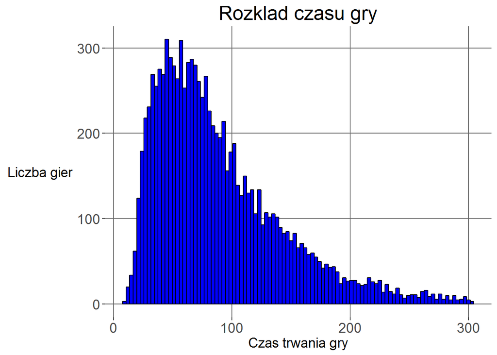

```r
library(ggplot2)

ggplot(czasy_trim,aes(czasy_trim))+
    geom_histogram(binwidth = 3, col="black",fill="blue")+
    theme(axis.text = element_text(size = 14),
    panel.grid.major = element_line(colour = "grey40"),
    panel.grid.minor = element_blank(),
    panel.background = element_rect(fill = "white"),
    axis.title=element_text(size=14),
    axis.title.y=element_text(angle=0),
    plot.title=element_text(size=20))+
    xlab("Czas trwania gry")+
    ylab("Liczba gier")+
    labs(title="Rozkład czasu gry")
```

# 4 Co dalej?

Kolejnymi krokami, które planujemy będą:

- dodanie kolejnych strategii i porównanie rozkładów czasu gry
- wizualnizacja różnic między strategiami
- przepisanie funkcji, by nie wykorzystywały zmiennych globalnych
- przerobienie funkcji strategii na bardziej elegancką (być może zastosowanie fun factory)
- dalsza praca nad estetyką kodu, zamiana pętli na funkcje R-owe, porównanie czasu wykonania kodu.